[figure not shown]

*Copyright Pierian Data*

*For more information, visit us at www.pieriandata.com*

# Time Resampling

Let's learn how to sample time series data! This will be useful later on in the course!

```python
import pandas as pd
%matplotlib inline
```

## Import the data

For this exercise we'll look at Starbucks stock data from 2015 to 2018 which includes daily closing prices and trading volumes.

```python
# Index_col indicates that the index will be the column called 'Date'
# parse_dates, transforms the strings into datetime format

df = pd.read_csv('../Data/starbucks.csv', index_col='Date', parse_dates=True)
```

Note: the above code is a faster way of doing the following:

```
df = pd.read_csv('../Data/starbucks.csv')
df['Date'] = pd.to_datetime(df['Date'])
df.set_index('Date',inplace=True)
```

```python
df.head()
```

| Date | Close | Volume |
| --- | --- | --- |
| 2015-01-02 | 38.0061 | 6906098 |
| 2015-01-05 | 37.2781 | 11623796 |
| 2015-01-06 | 36.9748 | 7664340 |
| 2015-01-07 | 37.8848 | 9732554 |
| 2015-01-08 | 38.4961 | 13170548 |

## resample()

A common operation with time series data is resampling based on the time series index. Let's see how to use the resample() method. [[reference](https://pandas.pydata.org/pandas-docs/stable/generated/pandas.DataFrame.resample.html)]

```python
# Our index
df.index
```

```
DatetimeIndex(['2015-01-02', '2015-01-05', '2015-01-06', '2015-01-07',
               '2015-01-08', '2015-01-09', '2015-01-12', '2015-01-13',
               '2015-01-14', '2015-01-15',
               ...
               '2018-12-17', '2018-12-18', '2018-12-19', '2018-12-20',
               '2018-12-21', '2018-12-24', '2018-12-26', '2018-12-27',
               '2018-12-28', '2018-12-31'],
              dtype='datetime64[ns]', name='Date', length=1006, freq=None)
```

When calling `.resample()` you first need to pass in a **rule** parameter, then you need to call some sort of aggregation function.

The **rule** parameter describes the frequency with which to apply the aggregation function (daily, monthly, yearly, etc.)  
It is passed in using an "offset alias" - refer to the table below. [[reference](http://pandas.pydata.org/pandas-docs/stable/user_guide/timeseries.html#offset-aliases)]

The aggregation function is needed because, due to resampling, we need some sort of mathematical rule to join the rows (mean, sum, count, etc.)

**TIME SERIES OFFSET ALIASES**

| ALIAS | DESCRIPTION |
| --- | --- |
| B | business day frequency |
| C | custom business day frequency (experimental) |
| D | calendar day frequency |
| W | weekly frequency |
| M | month end frequency |
| SM | semi-month end frequency (15th and end of month) |
| BM | business month end frequency |
| CBM | custom business month end frequency |
| MS | month start frequency |
| SMS | semi-month start frequency (1st and 15th) |
| BMS | business month start frequency |
| CBMS | custom business month start frequency |
| Q | quarter end frequency |
|  | intentionally left blank |

| ALIAS | DESCRIPTION |
| --- | --- |
| BQ | business quarter endfrequency |
| QS | quarter start frequency |
| BQS | business quarter start frequency |
| A | year end frequency |
| BA | business year end frequency |
| AS | year start frequency |
| BAS | business year start frequency |
| BH | business hour frequency |
| H | hourly frequency |
| T, min | minutely frequency |
| S | secondly frequency |
| L, ms | milliseconds |
| U, us | microseconds |
| N | nanoseconds |

Let's resample our dataframe, by using rule "A", which is year and frecuency and aggregate it with the mean

```python
# Yearly Means
df.resample(rule='A').mean()
```

| Date | Close | Volume |
| --- | --- | --- |
| 2015-12-31 | 50.078100 | 8.649190e+06 |
| 2016-12-31 | 53.891732 | 9.300633e+06 |
| 2017-12-31 | 55.457310 | 9.296078e+06 |
| 2018-12-31 | 56.870005 | 1.122883e+07 |

Resampling rule 'A' takes all of the data points in a given year, applies the aggregation function (in this case we calculate the mean), and reports the result as the last day of that year.

### Custom Resampling Functions

We're not limited to pandas built-in summary functions (min/max/mean etc.). We can define our own function:

```python
def first_day(entry):
    """
    Returns the first instance of the period, regardless of sampling rate.
    """
    if len(entry):  # handles the case of missing data
        return entry[0]
```

```python
df.resample(rule='A').apply(first_day)
```

| Date | Close | Volume |
| --- | --- | --- |
| 2015-12-31 | 38.0061 | 6906098 |
| 2016-12-31 | 55.0780 | 13521544 |
| 2017-12-31 | 53.1100 | 7809307 |
| 2018-12-31 | 56.3243 | 7215978 |

### Plotting

Let's plot the average closing price per year

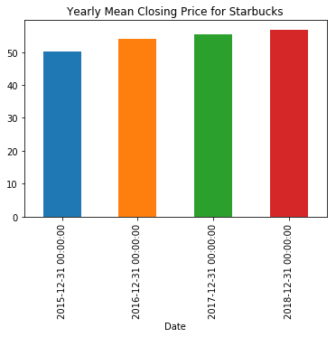

```python
df['Close'].resample('A').mean().plot.bar(title='Yearly Mean Closing Price for Starbucks');
```

Pandas treats each sample as its own trace, and by default assigns different colors to each one. If you want, you can pass a **color** argument to assign your own color collection, or to set a uniform color. For example, `color='#1f77b4'` sets a uniform "steel blue" color.

Also, the above code can be broken into two lines for improved readability.

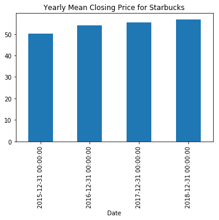

```python
title = 'Yearly Mean Closing Price for Starbucks'
df['Close'].resample('A').mean().plot.bar(title=title,color=['#1f77b4']);
```

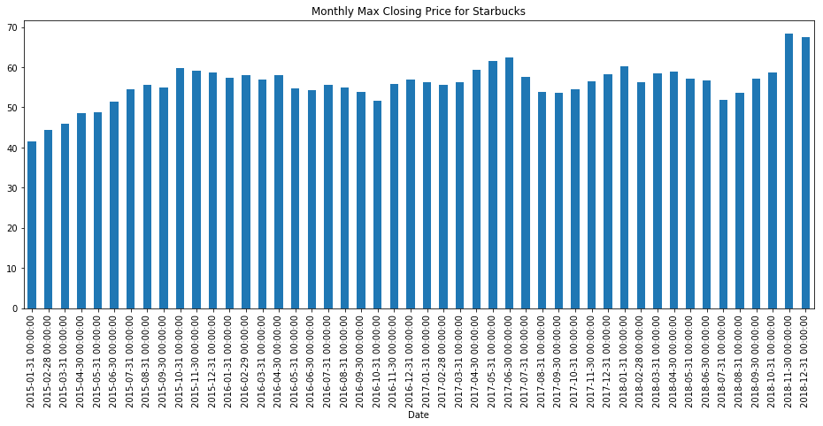

```python
title = 'Monthly Max Closing Price for Starbucks'
df['Close'].resample('M').max().plot.bar(figsize=(16,6), title=title,color='#1f77b4');
```

That is it! Up next we'll learn about time shifts!